# 2_150-Analyze activations 1

```python
import numpy as np
import matplotlib.pyplot as pl
from scipy.stats.stats import pearsonr


from create_dictionaries import create_dictionaries
import copy


from itertools import cycle
from sklearn.linear_model import Lasso, ElasticNet, lasso_path, enet_path
from sklearn.linear_model import LassoCV, ElasticNetCV, LassoLarsCV, LassoLarsIC

from sklearn.model_selection import KFold

import json

import sys

from IPython.utils.io import Tee
```

```python
activations_name='weights0904-2d-30Hz-newinputs-dataaugmentation-30epochs'
#activations_folder="../activations/Scores_Ramus/weights_2020-04-07"
n_cells=128


metrics_folder='./corpus_ramus/Files/'

saveTxtFile=False #save best cells in text file

l1_ratio=0.2 #for ElasticNet
#NB further parameters: conservative, type of cells

saveCoeffs=False #save regression coeffs to json file
normalizeFeatures=False
```

```python
# Parameters
activations_name = "weights_2_150_voiced_unvoiced_bis_ALL"
n_cells = 150
```

```python
activations_folder=f'../activations/Scores_Ramus/{activations_name}'
```

```python
dfiles, d_match, datay, d_act, d_lang, D, dmetrics = create_dictionaries(activations_folder=activations_folder,
                                                           metrics_folder=metrics_folder)
```

### Metrics

```python
metrique_keys=['deltV', 'deltC', 'propV', 'varco_V', 'varco_C', 'nPVI_V', 'rPVI_C']
list_files=list(d_match.keys())

metric_arrays={}
for metrique in metrique_keys:
    l=[]
    for file in list_files:
        l.append(dmetrics[file][metrique])
    metric_arrays[metrique]=np.array(l)
```

Figures metrics (NB: they differ slightly from Ramus' figures as not every audio file was available, especially for English)

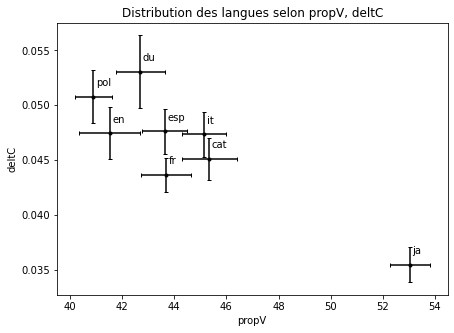

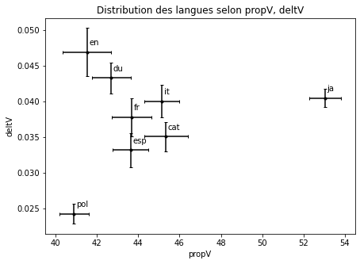

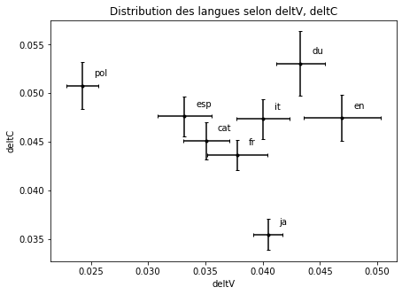

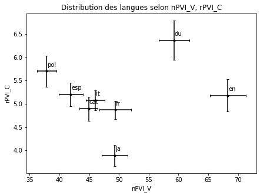

```python
metrique_tuples=[('propV', 'deltC'), ('propV', 'deltV'), ('deltV', 'deltC'), ('nPVI_V', 'rPVI_C')]
plt=pl

for tup in metrique_tuples:
    plt.figure(figsize=(7,5))
    metrique_x, metrique_y = tup
    xarr=metric_arrays[metrique_x]
    yarr=metric_arrays[metrique_y]


    if metrique_x in ['deltC', 'deltV']:
        shift_x=0.001
    elif metrique_x in ['propV', 'nPVI_V', 'rPVI_C']:
        shift_x=0.1

    if metrique_y in ['deltC', 'deltV']:
        shift_y=0.001
    elif metrique_y in ['propV', 'nPVI_V', 'rPVI_C']:
        shift_y=0.1
    for lang in D:
        xarr_lang=[]
        yarr_lang=[]
        for j, file in enumerate(list_files):
            if d_lang[file] == lang:
                xarr_lang.append(xarr[j])
                yarr_lang.append(yarr[j])
        xarr_lang=np.array(xarr_lang)
        yarr_lang=np.array(yarr_lang)
        std=np.std(xarr_lang)
        xsterr=std/np.sqrt(len(xarr_lang))
        std=np.std(yarr_lang)
        ysterr=std/(np.sqrt(len(yarr_lang)))
        x,y=np.mean(xarr_lang),np.mean(yarr_lang)
        plt.errorbar(x,y,label=lang,fmt=".k",xerr=xsterr,yerr=ysterr,capsize=2)
        plt.text(x+shift_x,y+shift_y,lang)

    plt.title(f"Distribution des langues selon {metrique_x}, {metrique_y}")
    plt.xlabel(metrique_x)
    plt.ylabel(metrique_y)
    plt.show()
```

### Pearson coefficients

NB: Pearson coefficients are signed (contrary to original version where it was the absolute value)

```python
pearson={}

for metrique in metrique_keys:
    pearson[metrique]={'lstm_1':{'cell_states':[],'outputs':[]},'lstm_2':{'cell_states':[],'outputs':[]}}

for lstm in ['lstm_1','lstm_2']:
    for celltype in ['outputs','cell_states']:
        for i in range(n_cells): #i passe sur chacune des cellules
            y=[]
            for file in list_files:
                audio=d_match[file].split('.')[0]
                y.append(datay[audio][lstm][celltype][i])
            y=np.array(y).astype(np.float)

            for metrique in metrique_keys:
                x=metric_arrays[metrique]
                pearson[metrique][lstm][celltype].append(pearsonr(y,x)[0])
```

Meilleures cellules

```python
##Meilleures cellules
'''
d1={}
for metrique in list(pearson.keys()):
    d1[metrique]=[]
    for lstm in list(pearson[metrique].keys()):
        for celltype in list(pearson[metrique][lstm].keys()):
            d1[metrique]=d1[metrique]+pearson[metrique][lstm][celltype]
'''

if saveTxtFile:
    #f=open(f'./corpus_ramus/best_cells_{activations_name}.txt', 'w')
    #orig_stdout = sys.stdout
    #sys.stdout=f
    tee=Tee(f'./corpus_ramus/best_cells_{activations_name}.txt')

for metrique in list(pearson.keys()):
    pearson2 = copy.deepcopy(pearson)
    print(metrique)
    max_ref_previous=np.inf
    for i in range(5):
        max_ref=-np.inf
        for lstm in list(pearson2[metrique].keys()):
            for celltype in list(pearson2[metrique][lstm].keys()):
                for ind, act in enumerate(pearson2[metrique][lstm][celltype]):
                    if max_ref<np.abs(act) and np.abs(act)<max_ref_previous:
                        ind_max=lstm, celltype, ind
                        max_ref=np.abs(act)
        lstm, celltype, ind=ind_max
        text=lstm+", "+celltype+", "+str(ind)+'\t\t'
        print(text,max_ref)
        max_ref_previous=max_ref
    print("\n")


if saveTxtFile:
    tee.close()
    #f.close()
    #sys.stdout=orig_stdout
```

```
deltV
lstm_2, cell_states, 49		 0.3689776597306671
lstm_2, cell_states, 36		 0.3680320013286456
lstm_2, outputs, 88		 0.34628539126637936
lstm_2, outputs, 51		 0.34383809066805654
lstm_2, cell_states, 51		 0.34095421487203703


deltC
lstm_1, outputs, 3		 0.4534718509891723
lstm_1, cell_states, 3		 0.4506392162252305
lstm_1, cell_states, 51		 0.36374490379362534
lstm_1, outputs, 51		 0.3333297666505066
lstm_2, cell_states, 126		 0.32234809249489815


propV
lstm_2, cell_states, 35		 0.5159651733009365
lstm_2, outputs, 35		 0.4985352339979508
lstm_2, cell_states, 82		 0.48276053426729537
lstm_2, cell_states, 54		 0.47596042491406887
lstm_2, cell_states, 144		 0.4683552173518527


varco_V
lstm_2, cell_states, 64		 0.31585891815269485
lstm_2, outputs, 64		 0.3152343254749988
lstm_2, cell_states, 49		 0.306683036442078
lstm_2, cell_states, 36		 0.30545091782915135
lstm_2, outputs, 51		 0.30107630490875653


varco_C
lstm_1, outputs, 3		 0.2932430510879917
lstm_1, cell_states, 3		 0.29031834826730984
lstm_1, outputs, 131		 0.25080252112755025
lstm_1, cell_states, 131		 0.21140309775863725
lstm_1, cell_states, 28		 0.19810116031030836


nPVI_V
lstm_2, outputs, 64		 0.46744099891837587
lstm_2, cell_states, 64		 0.46557907564320145
lstm_2, cell_states, 36		 0.44177625506277024
lstm_2, cell_states, 89		 0.4181265438714806
lstm_2, outputs, 89		 0.4161945234667573


rPVI_C
lstm_2, outputs, 112		 0.3986798974818543
lstm_2, cell_states, 112		 0.36969689499742914
lstm_2, cell_states, 3		 0.36293515195944276
lstm_2, outputs, 3		 0.35342045425501745
lstm_1, outputs, 140		 0.34561645628994847
```

Figures

plt=pl pearsonabs=copy.deepcopy(pearson) for metrique in pearson: for lstm in list(pearson[metrique].keys()): for celltype in list(pearson[metrique][lstm].keys()): pearsonabs[metrique][lstm][celltype]=np.abs(pearson[metrique][lstm][celltype]) plt.figure() plt.hist(pearsonabs['deltV']['lstm_1']['outputs']) plt.title('Coef de corrélation des cellules output de la lstm1, métrique delta V') #plt.savefig('pearsonabs_lstm1_output_deltav.pdf') #plt.close() plt.figure() plt.hist(pearsonabs['deltV']['lstm_1']['cell_states']) plt.title('Coef de corrélation des cellules mémoire de la lstm1, métrique delta V') #plt.savefig('pearsonabs_lstm1_cellstates_deltav.pdf') #plt.close() plt.figure() plt.hist(pearsonabs['deltV']['lstm_2']['outputs']) plt.title('Coef de corrélation des cellules output de la lstm2, métrique delta V') #plt.savefig('pearsonabs_lstm2_output_deltav.pdf') #plt.close() plt.figure() plt.hist(pearsonabs['deltV']['lstm_2']['cell_states']) plt.title('Coef de corrélation des cellules mémoire de la lstm2, métrique delta V') #plt.savefig('pearsonabs_lstm2_cellstates_deltav.pdf') #plt.close() #delta C plt.figure() plt.hist(pearsonabs['deltC']['lstm_1']['outputs']) plt.title('Coef de corrélation des cellules output de la lstm1, métrique delta C') #plt.savefig('pearsonabs_lstm1_output_deltac.pdf') #plt.close() plt.figure() plt.hist(pearsonabs['deltC']['lstm_1']['cell_states']) plt.title('Coef de corrélation des cellules mémoire de la lstm1, métrique delta C') #plt.savefig('pearsonabs_lstm1_cellstates_deltac.pdf') #plt.close() plt.figure() plt.hist(pearsonabs['deltC']['lstm_2']['outputs']) plt.title('Coef de corrélation des cellules output de la lstm2, métrique delta C') #plt.savefig('pearsonabs_lstm2_output_deltac.pdf') #plt.close() plt.figure() plt.hist(pearsonabs['deltC']['lstm_2']['cell_states']) plt.title('Coef de corrélation des cellules mémoire de la lstm2, métrique delta C') #plt.savefig('pearsonabs_lstm2_cellstates_deltac.pdf') #plt.close() #prop V plt.figure() plt.hist(pearsonabs['propV']['lstm_1']['outputs']) plt.title('Coef de corrélation des cellules output de la lstm1, métrique prop V') #plt.savefig('pearsonabs_lstm1_output_propv.pdf') #plt.close() plt.figure() plt.hist(pearsonabs['propV']['lstm_1']['cell_states']) plt.title('Coef de corrélation des cellules mémoire de la lstm1, métrique prop V') #plt.savefig('pearsonabs_lstm1_cellstates_propv.pdf') #plt.close() plt.figure() plt.hist(pearsonabs['propV']['lstm_2']['outputs']) plt.title('Coef de corrélation des cellules output de la lstm2, métrique prop V') #plt.savefig('pearsonabs_lstm2_output_propv.pdf') #plt.close() plt.figure() plt.hist(pearsonabs['propV']['lstm_2']['cell_states']) plt.title('Coef de corrélation des cellules mémoire de la lstm2, métrique prop V') #plt.savefig('pearsonabs_lstm2_cellstates_propv.pdf') #plt.close()

### Scatter plots

```python
metrique_inds={'deltV':0, 'deltC':1, 'propV':2}
c_lang={"en":'C0',"pol":'C1',"du":'C2',"fr":'C3',"esp":'C4',"it":'C5',"cat":'C6',"ja":'C7'}
```

```python
metrique_inds.keys()
```

```
dict_keys(['deltV', 'deltC', 'propV'])
```

layer_list=['lstm_1', 'lstm_2', 'lstm_2', 'lstm_2'] celltype_list=['outputs', 'outputs', 'outputs' , 'outputs'] # 'outputs','cell_states': ind_list=[3, 4, 116, 115, 121] metrique_list=['deltC', 'propV', 'nPVI_V', 'rPVI_C'] for layer, celltype, ind, metrique in zip(layer_list, celltype_list, ind_list, metrique_list): met_arr=[] y=[] c=[] for file in list_files: #metrique_ind=metrique_inds[metrique] #met_arr.append(dfiles[file][metrique_ind]) met_arr.append(dmetrics[file][metrique]) audio=d_match[file].split('.')[0] y.append(datay[audio][layer][celltype][ind]) c.append(c_lang[d_lang[file]]) y=np.array(y).astype(np.float) #HACK for legend from matplotlib.lines import Line2D custom_lines = [Line2D([0], [0], c=f'C{i}') for i in range(len(c_lang))] pl.figure(figsize=(8,6)) pl.scatter(met_arr, y, c=c) pl.xlabel(metrique) pl.legend(custom_lines, c_lang) pl.ylabel(f'{layer} {celltype} unit {ind}')

### (Regularized) linear regressions

```python
#reference layer
layer='lstm_2'
celltype='outputs'


#metric_coeffs={'propV':0.05, 'deltC':20, 'deltV':20, 'nPVI_V':0.02, 'rPVI_C':0.15} #the metrics are first multiplied by these coeffs (y in [0, 1] range)
metric_coeffs=dict([(metrique, 1./metric_arrays[metrique].std()) for metrique in metrique_keys])
```

for metrique in metrique_keys: print(f'std {metrique} : {metric_arrays[metrique].std()}')

Matrix of activations / metric vectors

```python
X=np.zeros((n_cells, len(d_match)))

metric_arrays={}
for metrique in metrique_keys:
    l=[]
    for j, file in enumerate(list_files):
        l.append(dmetrics[file][metrique])
        audio=d_match[file].split('.')[0]
        X[:, j] = np.array(datay[audio][layer][celltype]).astype(np.float)
    metric_arrays[metrique]=np.array(l)
```

AIC/BIC criterion / CV

```
Computing regularization path using the coordinate descent lasso...
Computing regularization path using the elastic net...
Computing regularization path using the coordinate descent lasso...
Computing regularization path using the elastic net...
Computing regularization path using the coordinate descent lasso...
Computing regularization path using the elastic net...
Computing regularization path using the coordinate descent lasso...
Computing regularization path using the elastic net...
Computing regularization path using the coordinate descent lasso...
```

```
Computing regularization path using the elastic net...
Computing regularization path using the coordinate descent lasso...
Computing regularization path using the elastic net...
Computing regularization path using the coordinate descent lasso...
Computing regularization path using the elastic net...
```

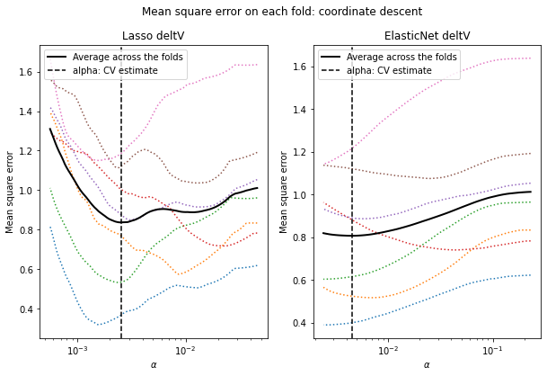

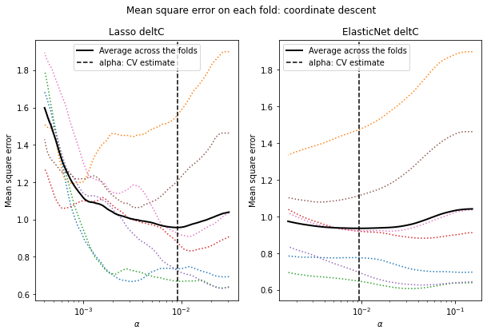

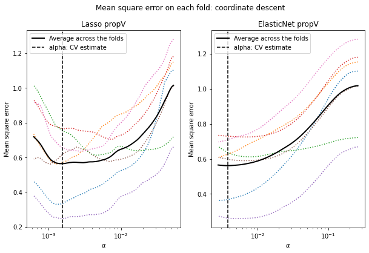

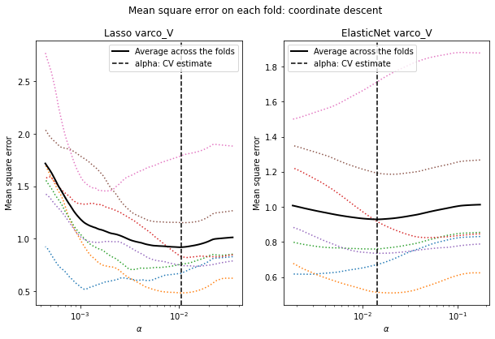

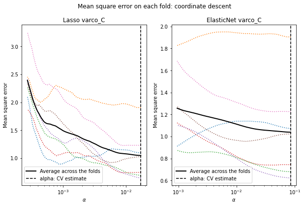

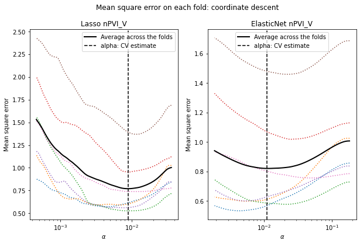

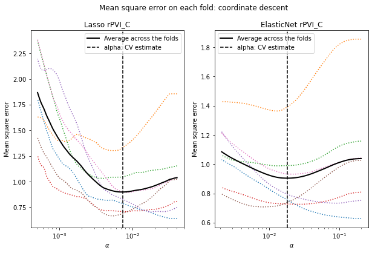

```python
#normalize data?
X2=np.copy(X)
XT=X2.T
if normalizeFeatures:
    XT -= np.mean(XT, axis=0)

    XT /= XT.std(axis=0)

k_fold=7
shuffling=False
EPSILON= 1e-4

random_state = 1 if shuffling else None
CVsplitter=KFold(n_splits=k_fold, shuffle=shuffling, random_state=random_state)

metric_alphaCV_lasso = {}
metric_alphaCV_enet = {}

plt=pl
for metrique in metric_arrays:
    try:
        y=metric_coeffs[metrique]*metric_arrays[metrique]
    except KeyError as e:
        print(f'{metrique} not in metric_coeffs, lasso not performed')
        continue
    '''
    model_bic = LassoLarsIC(criterion='bic')
    model_bic.fit(XT, y)

    alpha_bic_ = model_bic.alpha_

    model_aic = LassoLarsIC(criterion='aic')
    model_aic.fit(XT, y)
    alpha_aic_ = model_aic.alpha_


    def plot_ic_criterion(model, name, color):
        criterion_ = model.criterion_
        plt.semilogx(model.alphas_ + EPSILON, criterion_, '--', color=color,
                     linewidth=3, label='%s criterion' % name)
        plt.axvline(model.alpha_ + EPSILON, color=color, linewidth=3,
                    label='alpha: %s estimate' % name)
        plt.xlabel(r'$\alpha$')
        plt.ylabel('criterion')


    plt.figure()
    plot_ic_criterion(model_aic, 'AIC', 'b')
    plot_ic_criterion(model_bic, 'BIC', 'r')
    plt.legend()
    plt.title(f'Information-criterion for model selection {metrique}')

    '''

    # #############################################################################
    # LassoCV: coordinate descent

    # Compute paths

    eps = 1e-2  # the smaller it is the longer is the path

    print("Computing regularization path using the coordinate descent lasso...")
    model_lasso = LassoCV(cv=CVsplitter, eps=eps, fit_intercept=True).fit(XT, y)
    print("Computing regularization path using the elastic net...")
    model_enet = ElasticNetCV(cv=CVsplitter, l1_ratio=l1_ratio, eps=eps, fit_intercept=True).fit(XT, y)

    metric_alphaCV_lasso[metrique] = model_lasso.alpha_
    metric_alphaCV_enet[metrique] = model_enet.alpha_


    # Display results
    plt.figure(figsize=(10,6))
    plt.subplot(1, 2, 1)
    ymin, ymax = 0.02, 0.1
    plt.semilogx(model_lasso.alphas_ + EPSILON, model_lasso.mse_path_, ':')
    plt.plot(model_lasso.alphas_ + EPSILON, model_lasso.mse_path_.mean(axis=-1), 'k',
             label='Average across the folds', linewidth=2)
    plt.axvline(model_lasso.alpha_ + EPSILON, linestyle='--', color='k',
                label='alpha: CV estimate')

    plt.legend()

    plt.xlabel(r'$\alpha$')
    plt.ylabel('Mean square error')
    plt.title(f'Lasso {metrique}')
    plt.axis('tight')
    #plt.ylim(ymin, ymax)



    plt.subplot(1, 2, 2)
    plt.semilogx(model_enet.alphas_ + EPSILON, model_enet.mse_path_, ':')
    plt.plot(model_enet.alphas_ + EPSILON, model_enet.mse_path_.mean(axis=-1), 'k',
             label='Average across the folds', linewidth=2)
    plt.axvline(model_enet.alpha_ + EPSILON, linestyle='--', color='k',
                label='alpha: CV estimate')

    plt.legend()

    plt.xlabel(r'$\alpha$')
    plt.ylabel('Mean square error')
    plt.title(f'ElasticNet {metrique}')
    plt.axis('tight')
    #plt.ylim(ymin, ymax)


    plt.suptitle('Mean square error on each fold: coordinate descent')
```

Lasso/ENet path

```
deltV
Computing regularization path using the lasso...
Computing regularization path using the elastic net...
```

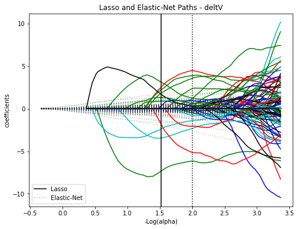

```
deltC
Computing regularization path using the lasso...
Computing regularization path using the elastic net...
```

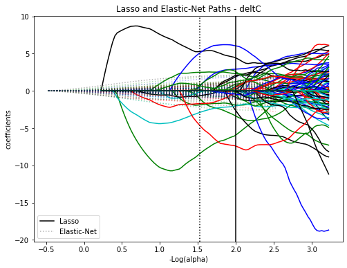

```
propV
Computing regularization path using the lasso...
Computing regularization path using the elastic net...
```

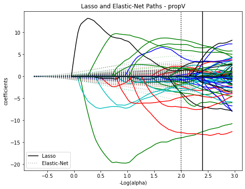

```
varco_V
Computing regularization path using the lasso...
Computing regularization path using the elastic net...
```

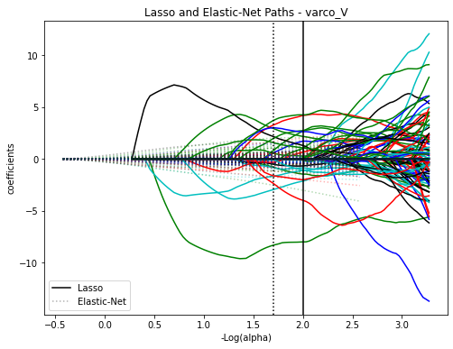

```
varco_C
Computing regularization path using the lasso...
Computing regularization path using the elastic net...
```

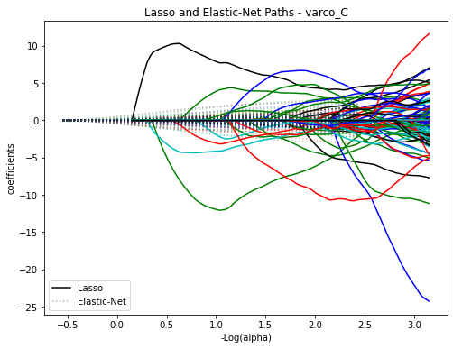

```
nPVI_V
Computing regularization path using the lasso...
Computing regularization path using the elastic net...
```

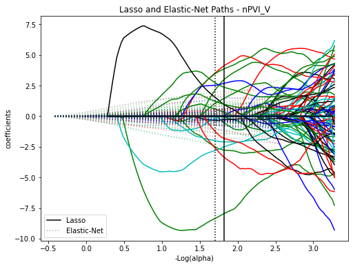

```
rPVI_C
Computing regularization path using the lasso...
Computing regularization path using the elastic net...
```

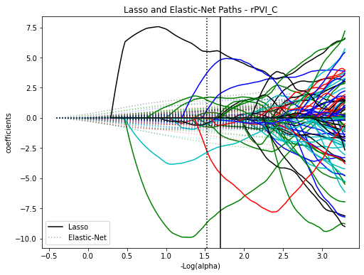

```python
#normalize data?
X2=np.copy(X)
XT=X2.T
if normalizeFeatures:
    XT -= np.mean(XT, axis=0)

    XT /= XT.std(axis=0)

metric_alphas_lasso = {}
metric_coefs_lasso = {}
metric_alphas_enet = {}
metric_coefs_enet = {}

for metrique in metric_arrays:
    try:
        y=metric_coeffs[metrique]*metric_arrays[metrique]
    except KeyError as e:
        print(f'{metrique} not in metric_coeffs, lasso not performed')
        continue

    # Compute paths

    eps = 1e-3  # the smaller it is the longer is the path

    print(metrique)
    print("Computing regularization path using the lasso...")
    alphas_lasso, coefs_lasso, _ = lasso_path(XT, y, eps=eps) #fit_intercept=True (deprecated)

    metric_alphas_lasso[metrique]=alphas_lasso
    metric_coefs_lasso[metrique]=coefs_lasso

    print("Computing regularization path using the elastic net...")
    alphas_enet, coefs_enet, _ = enet_path(
        XT, y, eps=eps, l1_ratio=l1_ratio) #fit_intercept=True (deprecated)


    metric_alphas_enet[metrique]=alphas_enet
    metric_coefs_enet[metrique]=coefs_enet


    # Display results
    plt=pl
    plt.figure(1, figsize=(8,6))
    colors = cycle(['b', 'r', 'g', 'c', 'k'])
    neg_log_alphas_lasso = -np.log10(alphas_lasso)
    neg_log_alphas_enet = -np.log10(alphas_enet)
    for coef_l, coef_e, c in zip(coefs_lasso, coefs_enet, colors):
        l1 = plt.plot(neg_log_alphas_lasso, coef_l, c=c)
        l2 = plt.plot(neg_log_alphas_enet, coef_e, linestyle=':', c=c, alpha=0.30)

    plt.axvline(-np.log10(metric_alphaCV_lasso[metrique]), linestyle='-', color='k')
    plt.axvline(-np.log10(metric_alphaCV_enet[metrique]), linestyle=':', color='k')


    plt.xlabel('-Log(alpha)')
    plt.ylabel('coefficients')
    plt.title(f'Lasso and Elastic-Net Paths - {metrique}')
    plt.legend((l1[-1], l2[-1]), ('Lasso', 'Elastic-Net'), loc='lower left')
    plt.axis('tight')
    plt.show()
```

Lasso with custom alpha

```python
metric_alphaCV_lasso, metric_alphaCV_enet
```

```
({'deltV': 0.03,
  'deltC': 0.01,
  'propV': 0.004,
  'varco_V': 0.01,
  'varco_C': -0.002944350495534282,
  'nPVI_V': 0.015,
  'rPVI_C': 0.02},
 {'deltV': 0.01,
  'deltC': 0.03,
  'propV': 0.01,
  'varco_V': 0.02,
  'varco_C': -0.012944350495534282,
  'nPVI_V': 0.02,
  'rPVI_C': 0.03})
```

```python
metric_alpha_lasso_custom = metric_alphaCV_lasso
metric_alpha_enet_custom = metric_alphaCV_enet

conservative=True
#more conservative
if conservative:
    metric_alpha_lasso_custom['deltV']=0.03
    metric_alpha_lasso_custom['deltC']=0.01
    metric_alpha_lasso_custom['propV']=0.004
    metric_alpha_lasso_custom['varco_V']=0.01
    metric_alpha_lasso_custom['varco_C']=metric_alpha_lasso_custom['varco_C']-0.01
    metric_alpha_lasso_custom['nPVI_V']=0.015
    metric_alpha_lasso_custom['rPVI_C']=0.02

    metric_alpha_enet_custom['deltV']=0.01
    metric_alpha_enet_custom['deltC']=0.03
    metric_alpha_enet_custom['propV']=0.01
    metric_alpha_enet_custom['varco_V']=0.02
    metric_alpha_enet_custom['varco_C']=metric_alpha_lasso_custom['varco_C']-0.01
    metric_alpha_enet_custom['nPVI_V']=0.02
    metric_alpha_enet_custom['rPVI_C']=0.03
```

```python
metric_coeffs_lasso = {}  #double f, caution: a dictionary _coefs have been defined previously
metric_coeffs_enet = {}

metric_intercept_lasso = {}
metric_intercept_enet = {}

def print_coeffs(intercept, coeffs):
    st_l=[str(intercept)]
    for ind in np.nonzero(coeffs)[0]:
        st_l.append(f' + ({coeffs[ind]:0.4f})*x[{ind}]')
    print(''.join(st_l))

for metrique in metric_arrays:

    y=metric_coeffs[metrique]*metric_arrays[metrique]

    model_lasso = Lasso(alpha=metric_alpha_lasso_custom[metrique], fit_intercept=True)
    model_lasso.fit(XT, y)

    metric_intercept_lasso[metrique] = model_lasso.intercept_/metric_coeffs[metrique]
    metric_coeffs_lasso[metrique] = model_lasso.coef_/metric_coeffs[metrique] #XXX multiplied again by normalization factors
    if normalizeFeatures:
        metric_coeffs_lasso[metrique] /= X.std(axis=1)

    print(f'Lasso {metrique} : {np.count_nonzero(model_lasso.coef_)} non-zero coefficients')
    #print_coeffs(model_lasso.intercept_, model_lasso.coef_)

    model_enet = ElasticNet(alpha=metric_alpha_enet_custom[metrique], l1_ratio=l1_ratio, fit_intercept=True)
    model_enet.fit(XT, y)

    metric_intercept_enet[metrique] = model_enet.intercept_/metric_coeffs[metrique]
    metric_coeffs_enet[metrique] = model_enet.coef_/metric_coeffs[metrique]
    if normalizeFeatures:
        metric_coeffs_enet[metrique]/=X.std(axis=1)

    print(f'ElasticNet {metrique} : {np.count_nonzero(model_enet.coef_)} non-zero coefficients')
    #print_coeffs(model_enet.intercept_, model_enet.coef_)
```

```
Lasso deltV : 1 non-zero coefficients
ElasticNet deltV : 80 non-zero coefficients
Lasso deltC : 11 non-zero coefficients
ElasticNet deltC : 37 non-zero coefficients
Lasso propV : 26 non-zero coefficients
ElasticNet propV : 74 non-zero coefficients
Lasso varco_V : 8 non-zero coefficients
ElasticNet varco_V : 38 non-zero coefficients
Lasso varco_C : 150 non-zero coefficients
ElasticNet varco_C : 0 non-zero coefficients
Lasso nPVI_V : 5 non-zero coefficients
ElasticNet nPVI_V : 55 non-zero coefficients
Lasso rPVI_C : 7 non-zero coefficients
ElasticNet rPVI_C : 34 non-zero coefficients
```

Scatter plots

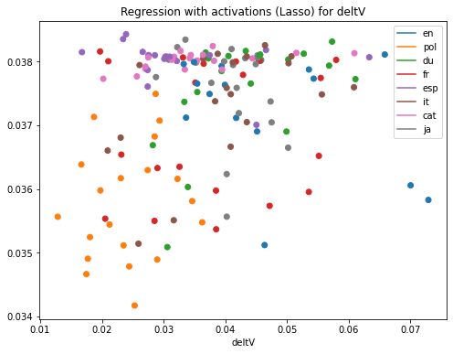

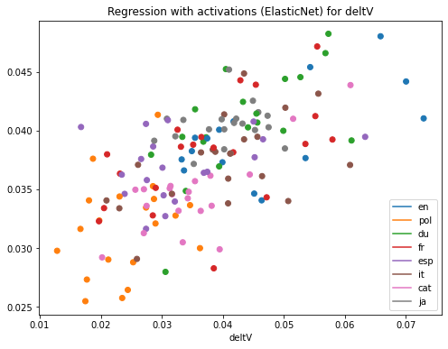

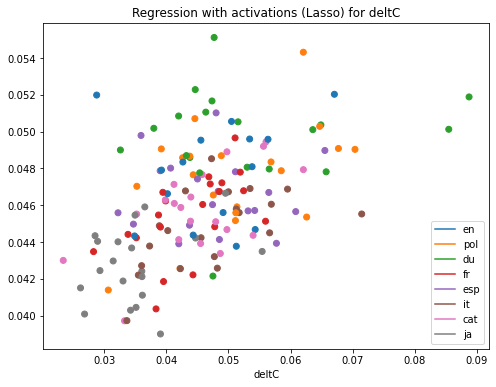

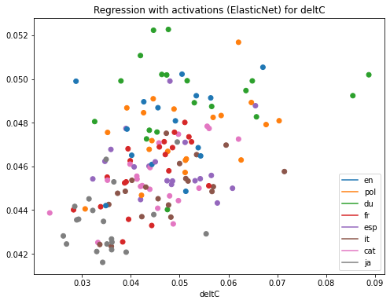

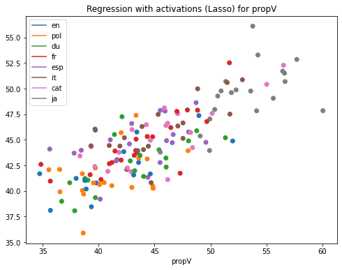

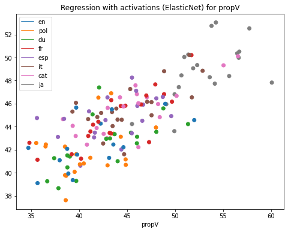

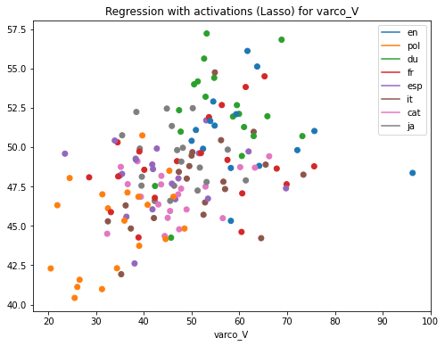

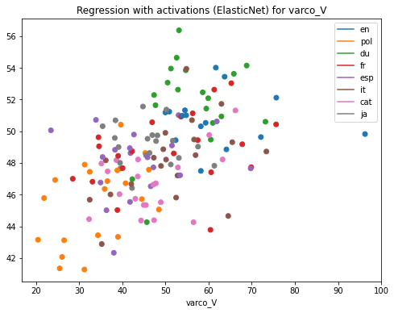

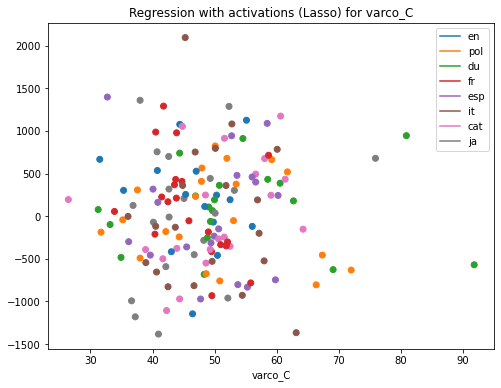

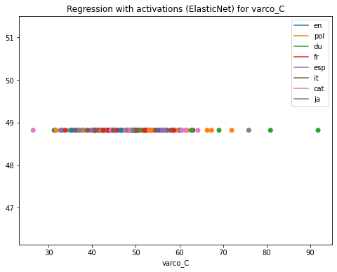

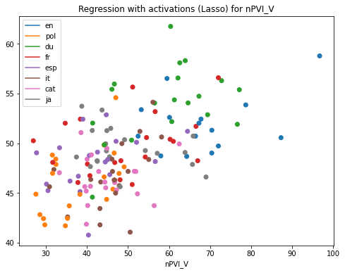

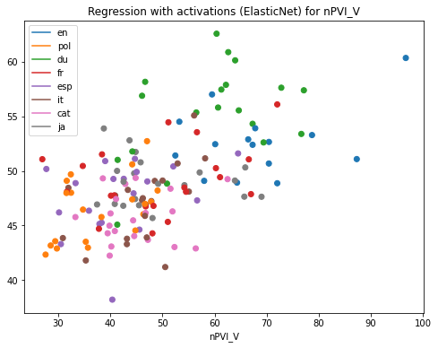

[2 more figures not shown]

```python
for metrique in metric_arrays:
    for (coeffs, intercept, name) in [(metric_coeffs_lasso[metrique], metric_intercept_lasso[metrique], 'Lasso'),
                                    (metric_coeffs_enet[metrique], metric_intercept_enet[metrique], 'ElasticNet')]:
        c=[]
        met_arr=metric_arrays[metrique]
        for file in list_files:
            c.append(c_lang[d_lang[file]])
        y=np.dot(X.T, coeffs)
        y+=intercept

        #HACK for legend
        from matplotlib.lines import Line2D
        custom_lines = [Line2D([0], [0], c=f'C{i}') for i in range(len(c_lang))]

        pl.figure(figsize=(8,6))
        pl.scatter(met_arr, y, c=c)
        pl.xlabel(metrique)
        pl.legend(custom_lines, c_lang)
        pl.title(f'Regression with activations ({name}) for {metrique}')
```

Save coeffs to JSON file

```python
if saveCoeffs:
    coeffs_dic={}
    for metrique in metric_arrays:
        dic={}
        dic['mult_factor']=metric_coeffs[metrique]

        dic2={}
        dic2['alpha']=metric_alpha_lasso_custom[metrique]
        dic2['coeffs']=list(metric_coeffs_lasso[metrique])
        dic2['intercept']=metric_intercept_lasso[metrique]

        dic['lasso']=dic2


        dic2={}
        dic2['alpha']=metric_alpha_enet_custom[metrique]
        dic2['coeffs']=list(metric_coeffs_enet[metrique])
        dic2['intercept']=metric_intercept_enet[metrique]

        dic['enet']=dic2

        coeffs_dic[metrique]=dic
    #activations_name=activations_folder.split('/')[-1]
    json_filename=activations_name
    if conservative:
        json_filename+='_conservative'
    with open(f'./corpus_ramus/coeffs/{json_filename}.json', 'w') as f:
        json.dump(coeffs_dic, f, sort_keys=True, indent=4)
```